[AIPLA](https://aipla.ku.dk/) [All guides](https://aipla.ku.dk/guides) [About the project](https://aipla.ku.dk/project) AI in Physics Learning and Assessment · Københavns Universitet

# Author with the AI co-pilot

AIPLA teacher guide — T4

Author

AIPLA project team

Published

July 14, 2026

**Where this fits**

The AI **co-pilot** lives inside the activity builder (guide *T2*). Instead of filling in every field by hand, you describe what you want to teach and the co-pilot proposes a teaching goal and workspace elements. You review each proposal and decide what to keep. Nothing changes until you approve it.

## What the co-pilot does

The co-pilot (labelled **Medbygger**) reads a plain-language description of your lesson and drafts:

- a **teaching goal** (the Socratic prompt the tutor follows),
- **workspace elements** — a checklist, a note, a table, a calculator, and so on, and
- suggested **curriculum materials** to attach (guide *T3*).

Each suggestion arrives as a **proposal** you can apply, edit, or dismiss. You stay in control: the co-pilot never changes the activity on its own.

## Step 1 — Open the builder

Create or open an activity (guide *T2*). The co-pilot panel sits at the **bottom-right** of the builder. It opens ready for a description.

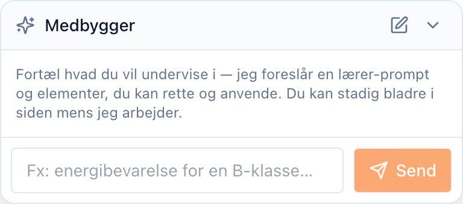

The co-pilot panel (Medbygger) sits at the bottom-right of the activity builder.

## Step 2 — Describe what you want to teach

Type a short description — for example, *“energy conservation for a 2.g class, with a checklist and a worked example”* — and select **Send**. The co-pilot thinks for a moment, then returns one or more proposals.

## Step 3 — Review each proposal

Each proposal is a card: a suggested teaching goal, a checklist, a note, a table, and so on. For each one you can:

- **Anvend** (Apply) — accept the suggestion into your draft,
- **Rediger** (Edit) — adjust it first, then apply, or
- **Afvis** (Dismiss) — reject it.

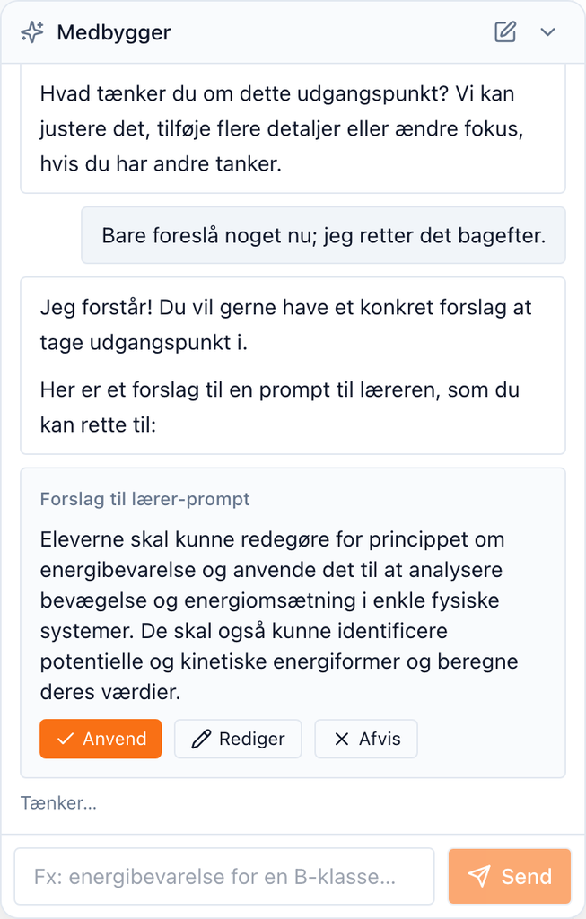

Each suggestion is a proposal card you can apply, edit, or dismiss.

## Step 4 — Apply and refine

When you apply a proposal, it drops into the matching field of the builder — and stays fully editable. Applied suggestions are marked so you can see what the co-pilot contributed. Keep refining by hand, or ask for more.

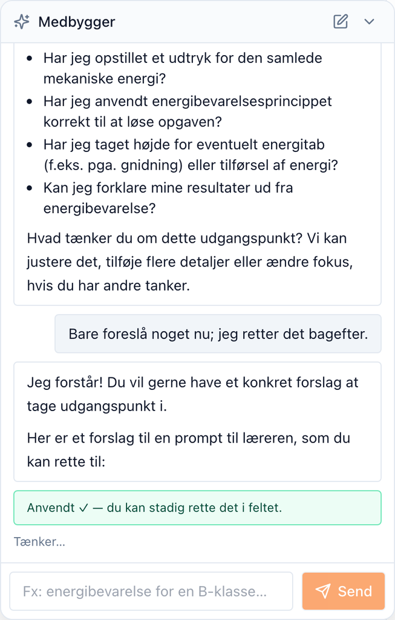

Applied suggestions land in the builder and remain editable.

When the activity looks right, **save** it as usual (guide *T2*). Nothing the co-pilot proposed is live until you save the activity.

**Tip**

The co-pilot proposes; you dispose. Every change waits for your **Anvend** (Apply), and even applied changes remain editable before you save — so it is safe to explore its suggestions freely.

## Next steps

- Attach source documents the tutor can cite — *T3 — Add and organise curriculum materials*.
- Share the activity with students — *T1 — Set up a class and share it*.